# LHF Data Analysis

SM & C Group

2023-03-21

# Analysis of Ladle Furnace Data

LHF data of ISP, Steel Melting Shop has been analysed using R. Data for the month of April’ 2022 has been collected from plant in form of MS Excel sheet. Aim of the analysis is to clean the data set and make an quick exploratry data analysis

## loading and cleaning of data set

```r
# data is in the data folder of the workig directory
df <- read_excel("data/aprildata.xlsx")
# converting the data set from tibble to data frame
df <- as.data.frame(df)
# selectig the columns LHF & from 2 to 12
df <- df %>% select(LHF, 2:12)

# only taking the complete data set
df <- subset(df, complete.cases(df))
# changing the variable names
mynames <- c("LHF", "Heat_No", "LADLE_IN", "ARCING_START", "ARCING_END",
             "INITIAL_TEMP", "FINAL_TEMP","Total_arcing_time",
             "C", "Si", "Mn", "S")

mynames <- tolower(mynames)

names(df) <- mynames

# taking the only the part of the data set in which EDA will be done
df <- df %>% select("lhf", "heat_no", "initial_temp", "final_temp",
                    "total_arcing_time", "c", "si", "mn", "s")

# recoding the factor lhf 2 and 1
df$lhf <- recode(df$lhf,  "LHF 2" = "lhf2", "LHF 1" = "lhf1" )

# taking the only the minutes of arching
df$total_arcing_time <- minute(df$total_arcing_time)
# creating columns of temp_increase
df_mod <- df%>% mutate (temp_increase = final_temp - initial_temp)
df_mod <- df_mod %>% select(-heat_no, - initial_temp, -final_temp)
```

Seeing the first 10 entries of the data set

```r
head(df_mod, 10)
```

```
##     lhf total_arcing_time    c   si   mn     s temp_increase
## 1  lhf2                16 0.19 0.23 0.91 0.012            18
## 2  lhf2                16 0.14 0.14 0.76 0.017            57
## 3  lhf1                 7 0.20 0.21 0.81 0.025            -9
## 4  lhf2                12 0.13 0.10 0.59 0.021            18
## 5  lhf1                21 0.15 0.18 0.71 0.011            54
## 6  lhf1                11 0.18 0.14 0.81 0.017            24
## 7  lhf1                15 0.23 0.21 0.88 0.015            18
## 8  lhf1                20 0.19 0.19 0.86 0.015            70
## 9  lhf1                14 0.17 0.15 0.60 0.015            71
## 11 lhf2                11 0.14 0.10 0.49 0.012            40
```

It has been found that there are some mis-typing in Si and Mn entries. Corrections has been done using the following codes

```r
my_id <- length(df_mod$si)

for(i in 1:my_id) {
    if(df_mod$si[i] > 1){
        df_mod$si[i] = df_mod$si[i]/100
    }
}

for(i in 1:my_id) {
    if(df_mod$mn[i] > 3){
        df_mod$mn[i] = df_mod$mn[i]/10
    }
}

for(i in 1:my_id) {
    if(df_mod$mn[i] > 3){
        df_mod$mn[i] = df_mod$mn[i]/10
    }
}
```

# Exploratory Data Analysis

Some exploratory data analysis done using the basic histogram, scatter plots and boxplots.

The output plots and codes are given below

### Scatter Plot of temperature increase vs arcig time

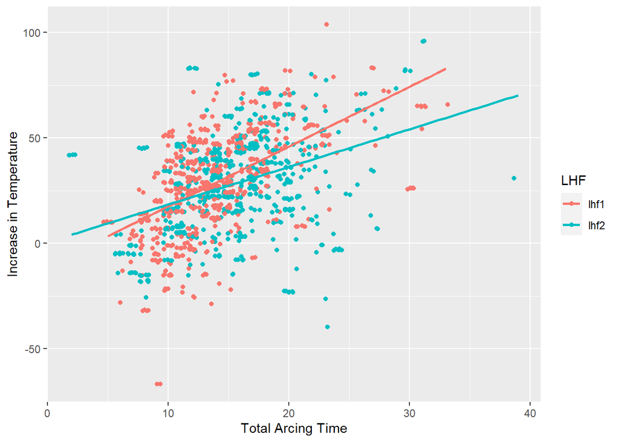

```r
# make basic scatter plot of arcing time vs temperature increase
sct_t_a <- ggplot(df_mod, aes(total_arcing_time,
                              temp_increase, color = lhf)) +
    geom_point(position = "jitter") +
    geom_smooth(method = "lm", se=F) +
    ylab("Increase in Temperature") +
    xlab("Total Arcing Time") +
    labs(color = "LHF")

print(sct_t_a)
```

### Histograms of arcing time and temperature increase

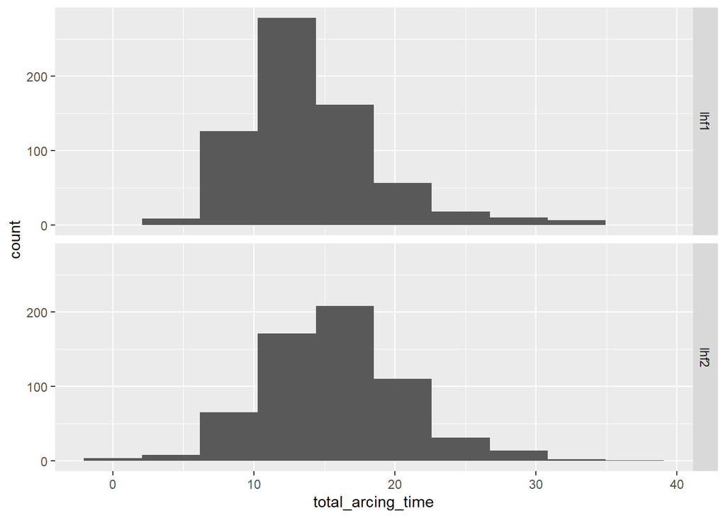

```r
# histogram
h_arctime <- ggplot(df_mod, aes(total_arcing_time)) +
    geom_histogram(bins = 10) +
    facet_grid(lhf ~ .)

print(h_arctime)
```

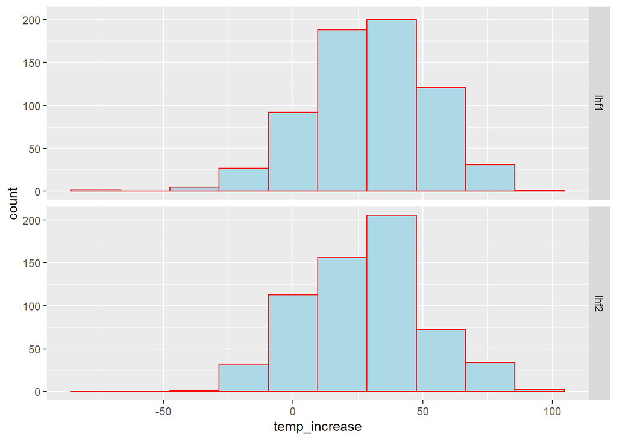

```r
h_temp_increase <- ggplot(df_mod, aes(temp_increase)) +
    geom_histogram(bins = 10, fill="light blue", color = "red") +
    facet_grid(lhf ~ .)

print(h_temp_increase)
```

## Box plot and density of chemistry

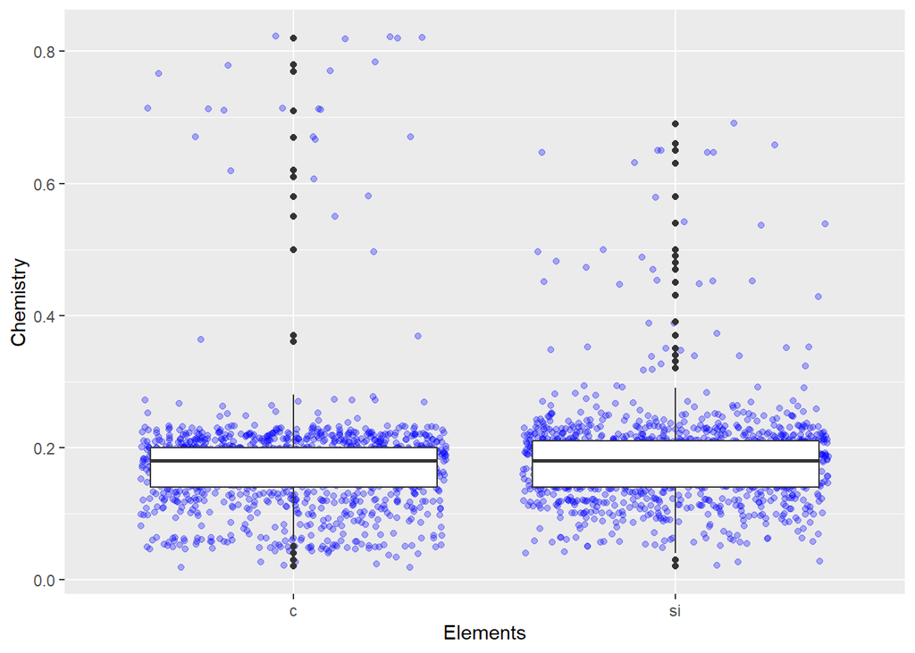

```r
# box_plot

df_mod2 <- df_mod %>% gather("c", "si",
                             key = "Elements", value = "Chemistry")




b_plot <- ggplot(df_mod2, aes(Elements, Chemistry)) +
    geom_point(color = "blue", alpha = .3, position = "jitter") +
    geom_boxplot()

print(b_plot )
```

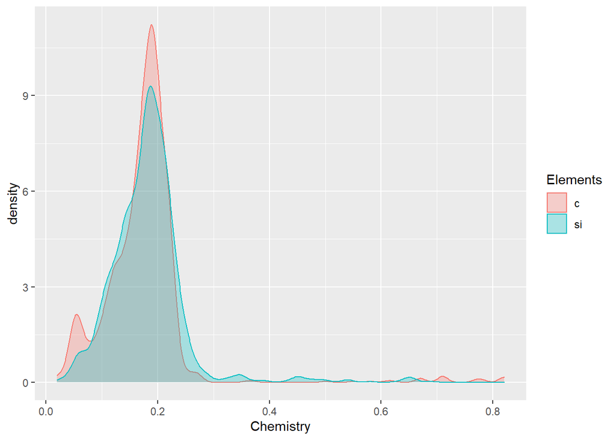

```r
d_plot <- ggplot(df_mod2, aes(x = Chemistry,
                    color = Elements, fill = Elements)) +
    geom_density(alpha = .3)

print(d_plot)
```

## Pair Plot matrix

All the variables and relationships among them in a single plot

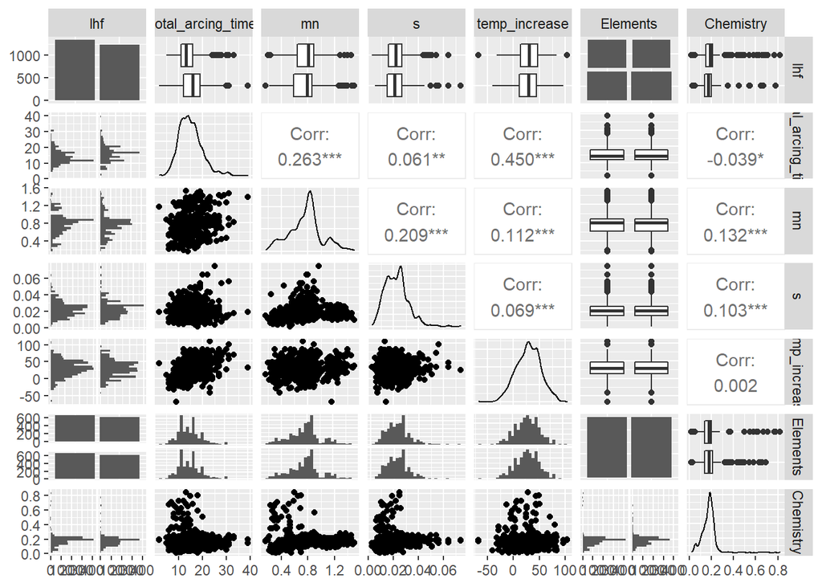